# Solving Heterogeneous-Agent Models by Projection and Perturbation (Reiter 2009)

### Roadmap

- Model
- Computational Challenge
- Reiter's Algorithm

## Model

- Households
- Firms
- Government

### Production

Output is produced by perfectly Competitive firms

$$ Y_{t}=Z_{t} A \bar{K}_{t-1}^{\alpha} L_{t}^{1-\alpha}, \quad 0<\alpha<1 $$$$ \bar{K}_{t}=(1-\delta) \bar{K}_{t-1}+Y_{t}-C_{t} $$$$ \log Z_{t+1}=\rho_{z} \log Z_{t}+\varepsilon_{Z, t+1} $$$$ \varepsilon_{Z, t+1}\sim N(0,\sigma_{z}) $$

Before tax interest rate $\bar{r}_{t}$ and the wage $w_{t}$ are determined by the FOCs

$$ \begin{array}{l} \bar{r}_{t}=\alpha Z_{t} A (\frac{\bar{K}_{t-1}}{L_{t}})^{\alpha -1} -\delta \\ w_{t}= (1-\alpha) Z_{t} A (\frac{\bar{K}_{t-1}}{L_{t}})^{\alpha } \end{array} $$

### Government

The government has to balance its budget every period, $$ T_{t}=\tau_{t} \bar{K}_{t-1} $$

The tax rate follows and AR(1) process around a steady state $\tau^{*}$,

$$ \tau_{t+1}-\tau^{*}=\rho_{\tau}\left(\tau_{t}-\tau^{*}\right)+\varepsilon_{\tau, t+1} $$$$ \varepsilon_{\tau, t+1}\sim N(0,\sigma_{\tau}) $$

The after tax interest rate is related to the tax rate by $$ r_{t}=\bar{r}_{t}-\tau_{t} $$

### Households

Continuum of infintely lived households of unit mass.

Household i's problem:

$$ \max _{\left\{c_{t ,i}\right\}_{t=0}^{\infty}}\left(\mathbb{E} \sum_{t=0}^{\infty} \beta^{t} \frac{c_{t ,i}^{1-\sigma}-1}{1-\sigma}\right) $$

subject to

$$ x_{t,i}= c_{t ,i} + k_{t ,i}=\left(1+r_{t}\right) k_{t-1, i}+w_{t} \xi_{t, i} + T_{t} $$$$ k_{t, i} \geqslant \underline{k} $$$$ \xi_{t, i} \ \text{is iid with density}\ f_{\xi}(.) $$

### Law of Motion for the Distribution of Capital

Let $\Psi_{t}(k)$ denote the the distribution function of capital.

Let $H$ describe the law of motion of the distribution of capital. $$\Psi_{t} = H(\Psi_{t-1})$$

### The dynamic program

Household i's problem is: \begin{eqnarray*} V( x_{t ,i}, Z_{t}, \tau_{t}, \Psi_{t-1}) &=& \max_{k_{t, i}}\{\frac{c_{t ,i}^{1-\sigma}-1}{1-\sigma} + \beta \mathbb{E} [V(x_{t+1, i} ,\tau_{t+1}, \Psi_{t}, Z_{t+1})]\} \\ c_{t ,i} + k_{t ,i} &=& (R_{t}(\Psi_{t-1}, Z_{t})) k_{t-1, i}+w_{t}(\Psi_{t-1}, Z_{t}) \xi_{t, i} + T \\ \Psi_{t} &=& H(\Psi_{t-1}, Z_{t},\tau_{t}) \\ &k_{t, i} \geqslant \underline{k}\\ \end{eqnarray*}

## The Computational Challenge?

$\Psi_{t}$ is a high dimensional endogenous state variable:

$k_{t,i}$ depends on expectations of $R_{t+1}(\bar{K}_{t}(\Psi_{t}, Z_{t+1}))$ and $w_{t+1}(\bar{K}_{t}(\Psi_{t}, Z_{t+1}))$

In other words, each agent $i$ needs to form expectations on the distribution of capital.

This will mean $H$ will be extremely difficult to solve.

## Reiter's Algorithm

## Reiter's Algorithm

Step 1: Discretize the Model

Step 2: Solve for steady state without aggregate shocks

Step 3: Peturb the steady state

## Key Ingredients of Reiter's Algorithm

Projection: Approximate $\Psi_{t}$ with vector $\mathbf{p}_t$

Pertubation: Use first order pertubation around the steady state

### Discretizing the Model

### Theoretical Model

Euler Equation

$$ U^{\prime}\left(C\left(x_{t, i} ; \Omega_{t}\right)\right)=\beta \mathrm{E}_{t}\left[R\left(\Omega_{t+1}\right) U^{\prime}\left(C\left(x_{t+1,i} ; \Omega_{t+1}\right)\right)\right], \quad \Omega_{t}=\left(Z_{t}, \tau_{t}, \Psi_{ t-1}\right) $$

Law of Motion for the Distribution of Capital

$$\Psi_{t} = H(\Psi_{t-1})$$

Government Budget Constraint

$$ T_{t}=\tau_{t} \bar{K}_{t-1} $$$$ \tau_{t+1}-\tau^{*}=\rho_{\tau}\left(\tau_{t}-\tau^{*}\right)+\varepsilon_{\tau, t+1} $$

Aggregate Productivity Process

$$ \log Z_{t+1}=\rho_{z} \log Z_{t}+\varepsilon_{Z, t+1} $$

### Discrete Model

Approximated Euler Equations

$$ U^{\prime}\left(\hat{C}\left(x_{t, i}, \Omega_{t}\right)\right)=\beta \sum_{j=1}^{n_{\xi}} \omega_{j}^{\xi}\left[R\left(\mathbf{p}_{t}, Z_{t+1}\right) U^{\prime}\left(\hat{C}\left(x_{t+1, i j}\right)\right)\right]+\eta_{i, t+1}^{c}, \quad i=0, \ldots, n_{p} $$

where $ x_{t+1, i j} \equiv R\left(\mathbf{p}_{t}, Z_{t+1}\right)\hat{K}(x_{t,i})+W\left(\mathbf{p}_{t}, Z_{t+1}\right) \hat{\xi}_{j}+T_{t+1} $

### Approximating the Distribution of Capital

$\Psi_{t}$ is approximated by vector $\mathbf{p}_{t}=(p_{t}^{1},..,p_{t}^{n_{d}})$ where

$$ p_{t}^{i}=\Psi_{t}\left(\kappa_{i}\right)-\Psi_{t}\left(\kappa_{i-1}\right) $$

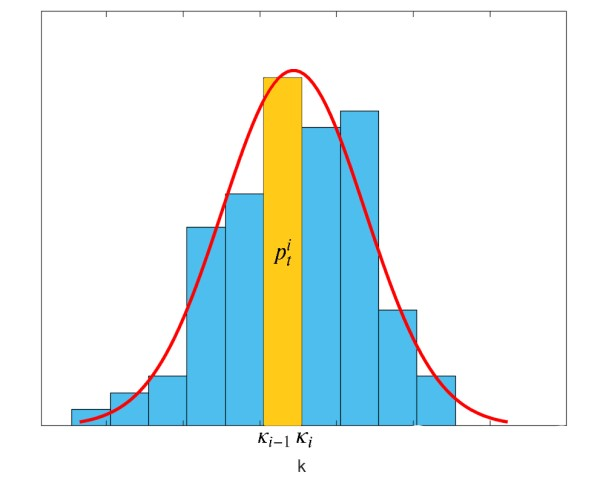

Then we can approximate $$\Psi_{t} = H(\Psi_{t-1})$$

by $$ \mathbf{p}_{t}=\Pi\left(\hat{\Omega}_{t}\right) \mathbf{p}_{t-1} $$

### Discrete Model

Approximated Euler Equations

$$ U^{\prime}\left(\hat{C}\left(x_{t, i}, \Omega_{t}\right)\right)=\beta \sum_{j=1}^{n_{\xi}} \omega_{j}^{\xi}\left[R\left(\mathbf{p}_{t}, Z_{t+1}\right) U^{\prime}\left(\hat{C}\left(x_{t+1, ij }\right)\right)\right]+\eta_{i, t+1}^{c}, \quad i=0, \ldots, n_{p} $$

where $ x_{t+1, i j} \equiv R\left(\mathbf{p}_{t}, Z_{t+1}\right)\hat{K}(x_{t,i})+W\left(\mathbf{p}_{t}, Z_{t+1}\right) \hat{\xi}_{j}+T_{t+1} $

Approximate Law of Motion for Distribution of Capital

$$ \mathbf{p}_{t}=\Pi\left(\hat{\Omega}_{t}\right) \mathbf{p}_{t-1} $$

Government Budget Constraint $$ T_{t}=\tau_{t} \bar{K}\left(\mathbf{p}_{t}\right) $$

$$ \tau_{t+1}-\tau^{*}=\rho_{\tau}\left(\tau_{t}-\tau^{*}\right)+\varepsilon_{\tau, t+1} $$

Aggregate Productivity Process

$$ \log Z_{t+1}=\rho_{z} \log Z_{t}+\varepsilon_{Z, t+1} $$

### Discrete Model as a System of Equations

$$ F\left(\Theta_{t-1}, \Theta_{t}, \varepsilon_{t}\right)=0 $$

where $ \Theta_{t} = (\hat{C}(x_{t,0}),...,\hat{C}(x_{t,n_{p}}),p_{t}^{1},...,p_{t}^{n_{d}},T_{t},r_{t},w_{t}) $ and $ \varepsilon_{t} = (\varepsilon_{Z, t}, \varepsilon_{\tau, t})$

Steady State with no aggregate shocks

$$ F\left(\Theta^{*}, \Theta^{*}, 0\right)=0 $$

### Solving the Steady State

### Step 1

Guess $K^{*}$ and obtain : $$ \begin{array}{l} T^{*}=\tau K^{*}\\ r^{*}=\alpha Z A (\frac{K^{*}}{L_{t}})^{\alpha -1} -\delta - \tau\\ w^{*}= (1-\alpha) Z A (\frac{K^{*}}{L_{t}})^{\alpha } \end{array} $$

Then we can solve for $\hat{C}\left(x_{i}^{*}\right)$:

$$ U^{\prime}\left(\hat{C}\left(x_{i}^{*}\right)\right)=\beta \sum_{j=1}^{n_{\xi}} \omega_{j}^{\xi}\left[\left(1+r^{*}\right) U^{\prime}\left(\hat{C}\left(\left(1+r^{*}\right) k^{*}\left(x_{i}^{*}\right)+w^{*} \hat{\xi}_{j}+T^{*}\right)\right)\right], \quad i=0, \ldots, n_{p} $$

### Step 2

Given the $r^{*}$, $T^{*}$ and $\hat{C}\left(x, \Omega \right)$, solve for the invariant distribution $\mathbf{p}^{*}$.

### Step 3

Check whether the guess of $K^{*}$ is consistent with $\mathbf{p}^{*}$:

$$K^{*} = \bar{K}(\mathbf{p}^{*}) $$

If $K^{*} \neq \bar{K}(\mathbf{p}^{*}) $ , go back to step 1 with an updated guess.

### Summary of the Algorithm

The discrete problem $$ F\left(\Theta_{t-1}, \Theta_{t}, \varepsilon_{t}\right)=0 $$

where $ \Theta_{t} = (\hat{C}(x_{t,0}),...,\hat{C}(x_{t,n_{p}}),p_{t}^{1},...,p_{t}^{n_{d}},T_{t},r_{t},w_{t}) $ and $ \varepsilon_{t} = (\varepsilon_{Z, t}, \varepsilon_{\tau, t})$

Steady State with no aggregate shocks $$ F\left(\Theta^{*}, \Theta^{*}, 0\right)=0 $$

First order pertubation $$ F_{1}\left(\Theta^{*}, \Theta^{*}, 0,0\right)\left(\Theta_{t-1}-\Theta^{*}\right)+F_{2}\left(\Theta^{*}, \Theta^{*}, 0,0\right)\left(\Theta_{t}-\Theta^{*}\right)+F_{3} \varepsilon_{t}=0 $$

This system can be solved by a Package of Sims(2001).

## References

Sims, C.A., 2001. Solving linear rational expectations models. Computational Economics 20(1–2),1–20.